# Problem Set 2

Behavioral Economics, Boston College

Sherry Peng TIAN

Oct 20, Fall 2019

*The assignment is worth **100 points**. There are **26 questions**. You should have the following packages installed:*

```r
rm(list = ls()) # Clear environment
library(tidyverse)
library(cowplot)
#install.packages("lfe")
library(lfe)
library(stargazer)
library(reshape2)
```

In this problem set you will summarize the paper [“Do Workers Work More if Wages Are High? Evidence from a Randomized Field Experiment”](https://www.aeaweb.org/articles?id=10.1257/aer.97.1.298) (Fehr and Goette, AER 2007) and recreate some of its findings.

# 1 Big picture

**1. What is the main question asked in this paper?**

Do workers work more if wages are high? The life-cycle model of labor supply predicting intertemporal substitution effect are highly restricted to transitory data, which is certainly under a large influence of income effect; therefore, the main question is to test out a better model which can seperately of the intertemperal substitution effect to understand the large variations in employment during business cycles as voluntary choices not involuntary layoffs.

**2. Recall the taxi cab studies where reference dependence is studied using observational data. What can an experimental study do that an observational study can’t?**

First of all, observational data means workers anticipate the wage change but in reality, they hardly do so, particularly predict a transitory change. Secondly, because both supply and demand determine wages, a serious endogeneity problem appreas. Hence, the experimental study rules out other externalities that influence the workers react to the income and/or substitution effect. Moreover, most of the time, workers are not free to set their working hours as the model suggesting, so there is another limitation of observational data. Overall, the experimental study used randomization and control group with the implementation of a fully anticipated, temporary, exogenous, and transitory variation in the wage rate.

**3. Summarize the field experiment design.**

The experiment utilizes data from Velobliz and Flash delivery companies and randomizes the participating workers into two groups A and B. Both of the groups got a chance of increased commission of 25% in one of the two periods, while the other group exists as a control group. Furthermore, the workers have the chance of choosing their own fixed shiifts as well as signing up for five hours straight.

**4. Summarize the laboratory experiment design. Why was it included with the study?**

The laboratory experiment measures loss aversion and reference dependent behaviors by observing individuals’ choices under uncertainty eight months after the experimental wage increase. The study includes two lotteries: Lottery A to win CHF 8 with probability a/2, or to lose CHF 5 with probability 1/2; Lottery B consiting of six independent repetitions of lottery A. Otherwise, the participants can reject each or both of the lotteries and earn 0 CHF.

**5. Summarize the main results of the field experiment.**

The experiment enables us 1. to clearly isolate the impact the temporary wage increase between two groups. 2. to contral for the income effect of wage increase. 3. to compare the time effects of two companies. Its result shows that messengers do work more hours if raising wages; however, the increase of work effort also depends on their psychological reference dependent points.

**6. Summarize the main results of the laboratory experiment.**

The degree of loss aversion is indeed related to the response of effort per shift. Higher degrees of loss aversion are associated with a stronger negative impact of the wage increase on effort per shift, and workers who do not display loss aversion in choices under uncertainty also do not show a significant effort reduction. Thus, it seems that loss aversion drives the negative effect of wages on effort.

**7. Why are these results valuable? What have we learned? Motivate your discussion with a real-world example.**

The paper introduces both the neoclasscial model of labor supply as well as the rational choice model, which explains the mathmatical intuition behind them. The experiments are done using observation, field experiment method, and lab experiment eliminating/understanding the effect of loss aversion. Meanwhile, the use of private company large datasets and advanced analytical approaches matter equally. As a result, the paper shows that only loss-averse individuals exhibit a negative effort response to the wage increase, which somehow is aligned but also contradicting the previous understanding.

Even the study utilizes loads of experiments in the psychology field, it covers a lot of labor supply models, which can help both the companies and governments monitor the labor market. For example, the way messengers choose work (fixed or sign-up) is similar to Uber or taxi drivers. Therefore, how drivers will react to the wage change or other compensation (some behaviors cannot be explained using theoritical models) is discussed in this paper.

# 2 Theory

**Suppose the messenger’s utility function is a static one-period utility function that is linear in incme**

$$v(e_t, x_t) = \gamma w_t e_t - g(e_t, x_t)$$
**where $w_t$ is the wage rate in time $t$, $e_t$ is the messenger’s effort, $\gamma$ is the marginal utility of lifetime wealth, and $g(e_t, x_t) = \frac{(\theta - x_t)e^2}{2}$ (which is strictly convex in $e_x$) is the messenger’s cost function constant disutility of effort $\theta$ and exogenous disutility shock $x_t \sim N(0,\sigma^2)$. Since $\mathbb{E}[x_t] = 0$, you can assume $x_t = 0$.**

**8. Show that the messenger chooses a level of effort so that the marginal benefit of working equals the marginal cost.**

Setting the f.o.c of utility function to 0 because of the maximum condition:
$$v(e_t, x_t) = \gamma w_te_t - \frac{(\theta - x_t)e_t^2}{2} \\
v'(e_t, x_t) = \gamma w_t - (\theta - x_t)e_t = 0 \\
\gamma w_t = (\theta - x_t)e_t \Rightarrow
e_t = \frac{\gamma w_t}{\theta - x_t} = \frac{\gamma w_t}{\theta}$$
The s.o.c of utility function requires:
$$v''(e_t, x_t) = -\theta < 0$$
**9. Show that the messenger in equilibrium responds to higher wages with higher effort.**

pg8: Workers respond to an anticiated temporary increase in $w_t$ with a higher effort $e_t$, so a rise in $w_t$ increases the marginal utility returns of effort, $\theta w_t$ will increase the effort level $e_t^*$ that maximizes $v(e_t, x_t)$.

**10. Write an R function that calculates $e_t^*$ for different levels of $w_t$. Set default values of $\theta=\gamma=1$. Then use `curve()` to plot the labor supply for $w_t \in [0,10]$.**

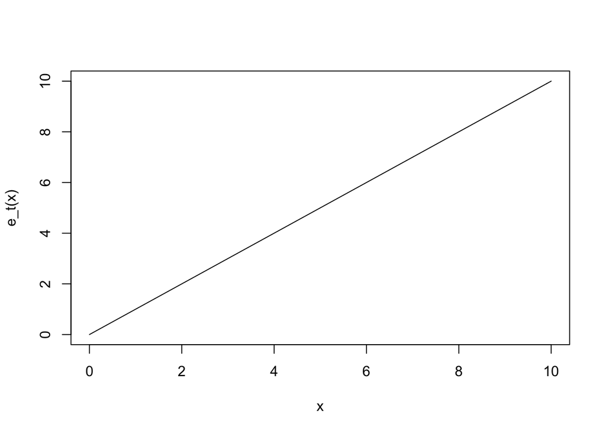

```r
e_t <- function(w_t) {
  e <- w_t/1
  return(e)
}
curve(e_t, 0, 10)
```

**11. Now suppose utility is given by**

$$v(e_t, x_t) =
\begin{cases}
\gamma(w_t e_t - r) - g(e_t, x_t) &\quad \text{if} \quad w_t e_t \geq r \\[1em]
\lambda\gamma(w_t e_t - r) - g(e_t, x_t) &\quad \text{if} \quad w_t e_t < r \\
\end{cases}$$

**12. Show that how the messenger in equilibrium responds to higher wages depends on the reference point $r$. (Hint: recall there are three cases to consider.)**

There are three conditions to consider with regarding to wage rate $w_t$:
$$e^*_t(w_t) =
\begin{cases}
\frac{\lambda \gamma w_t}{\theta} &\quad
\text{if} \quad w_t < \sqrt{\frac{\theta r}{\lambda \gamma}} \\
\frac{r}{w_t} &\quad
\text{if} \quad \sqrt{\frac{\theta r}{\lambda \gamma}} < w_t < \sqrt{\frac{\theta r}{\gamma}} \\
\frac{\gamma w_t}{\theta} &\quad
\text{if} \quad w_t > \sqrt{\frac{\theta r}{\gamma}}
\end{cases}$$

**13. Once more, write an R function that calculates $e_t^*$ for different levels of $w_t$. Set default values of $\theta=\gamma=1$, $\lambda = 2$ and $r=3$. Then use `curve()` to plot the labor supply for $w_t \in [0,10]$.**

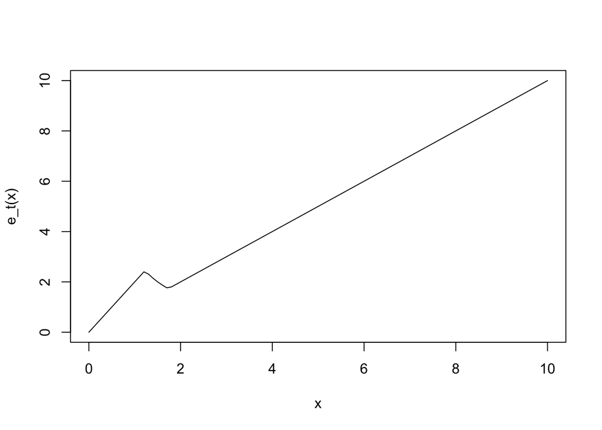

```r
e_t <- function(w) {
  e <- ifelse(w < sqrt(1*3/2), 2*1*w, ifelse(w > sqrt(1*3/1), w, 3/w))
  return(e)
}
curve(e_t, 0, 10)
```

# 3 Replication

*Use `theme_classic()` for all plots.*

## 3.1 Correlations in revenues across firms

*For this section please use `dailycorrs.csv`.*

**14. The authors show that earnings at Veloblitz and Flash are correlated. Show this with a scatter plot with a regression line and no confidence interval. Title your axes and the plot appropriately. Do not print the plot but assign it to an object called `p1`.**

```r
dailycorr <- read.csv("dailycorrs.csv")
p1 <- ggplot(dailycorr, aes(x=logv, y=logf)) +
  geom_point(size=2, shape=23) +
  geom_smooth(method=lm, se=FALSE, fullrange=FALSE, level=0.95) +
  labs(title = "Correlation Test of Delivery Companies", x = "log of Veloblitz", y = "log of Flash") +
  theme_classic()
```

**15. Next plot the kernel density estimates of revenues for both companies. Overlay the distributions and make the densities transparent so they are easily seen. Title your axes and the plot appropriately. Do not print the plot but assign it to an object called `p2`.**

```r
# should we $e^*$ back to revenues; create a new table - Doesn't matter with the shape
rev_delivery <- melt(exp(dailycorr))
```

```r
p2 <- ggplot(rev_delivery, aes(x = value, fill = variable)) +
  geom_density(alpha=0.4) +
  labs(title = "Kernel density estimates",
       x = "Revenues $", y = "Density") +
  theme_classic()
```

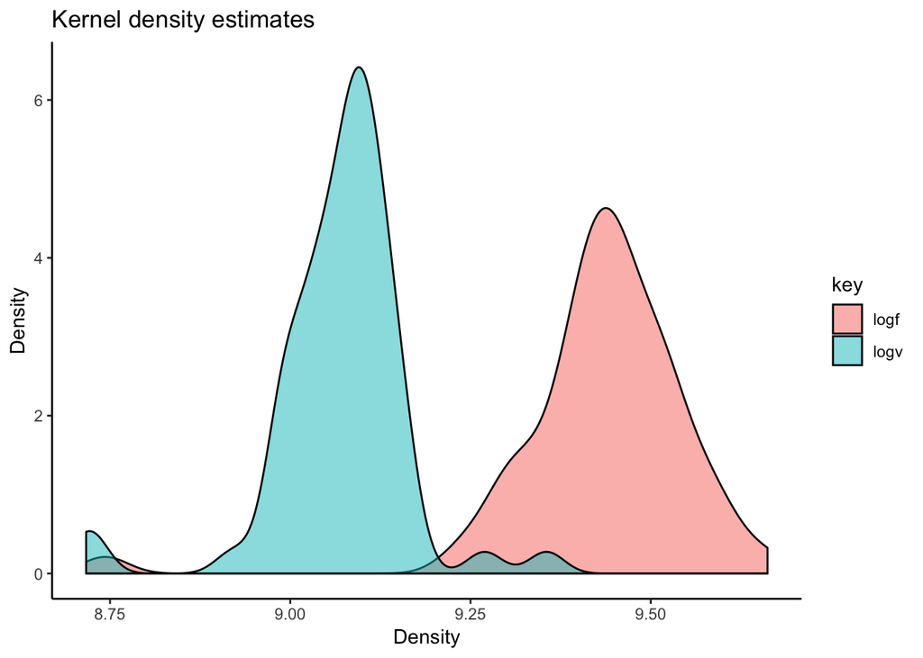

```r
# Alternatively,
dailycorr %>%
  gather() %>%
  ggplot(., aes(value, fill = key)) +
  geom_density(alpha = 0.5) +
  labs(title = "Kernel density estimates",
       x = "Density", y = "Density") +
  theme_classic()
```

**16. Now combine both plots using cowplot and label the plots with letters.**

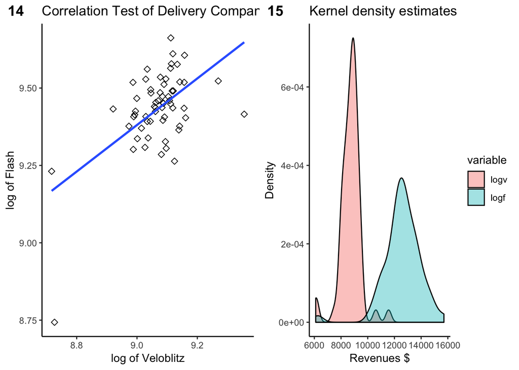

```r
plot_grid(p1, p2, labels = c('14', '15'), nrow = 1)
```

## 3.2 Tables 2 and 3

*For this section please use `tables1to4.csv`.*

### 3.2.1 Table 2

**On page 307 the authors write:**

> Table 2 controls for **individual fixed effects** by showing how, on average, the messengers’ revenues deviate from their person-specific mean revenues. Thus, a positive number here indicates a positive deviation from the person-specific mean; a negative number indicates a negative deviation.

**17. Fixed effects are a way to control for *heterogeneity* across individuals that is *time invariant.* Why would we want to control for fixed effects? Give a reason how bike messengers could be different from each other, and how these differences might not vary over time.**

By including fixed effects (group dummies), the study is controlling for the average differences in any observable or unobservable predictors; therefore, in this experimental data, a significant difference among labor supply might be the physical capacibility, which highly influence individuals’ choices and revenues and efforts. However, those differences don’t matter over time anymore, because there is a rotating cycle in the labor supply, where the main labor force will roughly the same to analyze.

**18. Create a variable called `totrev_fe` and add it to the dataframe. This requires you to “average out” each individual’s revenue for a block from their average revenue: $x_i^{fe} = x_{it} - \bar{x}_i$ where $x_i^{fe}$ is the fixed effect revenue for $i$.**

```r
df <- read_csv("tables1to4.csv")
df <- df %>%
  group_by(fahrer) %>%
  mutate(totrev_fe = totrev - mean(totrev))
```

**19. Use `summarise()` to recreate the findings in Table 2 for “Participating Messengers” using your new variable `totrev_fe`. (You do not have to calculate the differences in means.) In addition to calculating the fixed-effect controled means, calculate too the standard errors. Recall the standard error is $\frac{s_{jt}}{\sqrt{n_{jt}}}$ where $s_{jt}$ is the standard deviation for treatment $j$ in block $t$ and $n_{jt}$ are the corresponding number of observations. (Hint: use `n()` to count observations.) Each calculation should be named to a new variable. Assign the resulting dataframe to a new dataframe called `df_avg_revenue`.**

```r
df_avg_revenue <- df %>%
  group_by(odd, block) %>%
  summarise(avg_totrev = mean(totrev_fe), sd_totrev = sd(totrev_fe), count = n()) %>%
  mutate(se_rev = sd_totrev/sqrt(count))

df_avg_revenue
```

```
## # A tibble: 9 x 6
## # Groups:   odd [3]
##     odd block avg_totrev sd_totrev count se_rev
##   <int> <int>      <dbl>     <dbl> <int>  <dbl>
## 1     0     1     -120.      1319.    19  303.
## 2     0     2     -278.      1076.    20  241.
## 3     0     3      392.      1121.    20  251.
## 4     1     1      -48.9     1654.    21  361.
## 5     1     2      722.       905.    22  193.
## 6     1     3     -675.      1354.    22  289.
## 7    NA     1      345.       962.    80  108.
## 8    NA     2       38.5      843.    86   90.8
## 9    NA     3     -322.      1007.    96  103.
```

**20. Plot `df_avg_revenue`. Use points for the means and error bars for standard errors of the means. Note the following:**

- To dodge the points and size them appropriately, use `geom_point(position=position_dodge(width=0.5), size=4)`
- To place the error bars use `geom_errorbar(aes(x=block, ymin = [MEAN] - [SE], ymax = [MEAN] + [SE]),width = .1,position=position_dodge(width=0.5))`
  - You need to replace `[MEAN]` with whatever you named your average revenues and `[SE]` with whatever you named your standard errors.

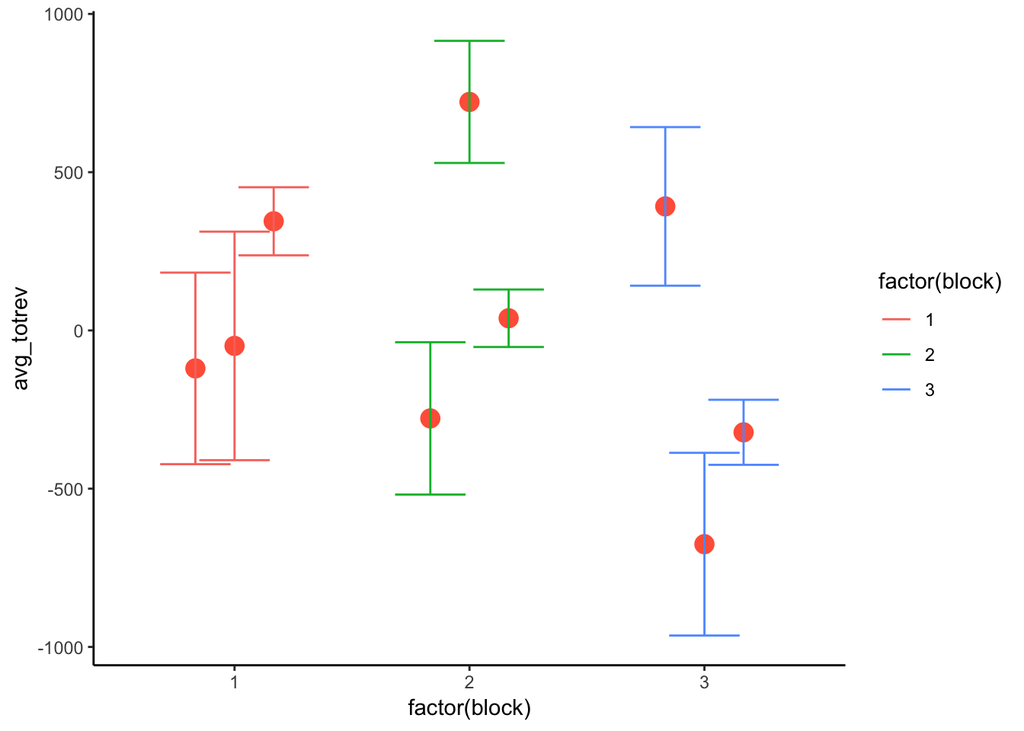

```r
df_avg_revenue %>%
  #na.omit(odd) %>%
  mutate(bottom = avg_totrev - se_rev, top = avg_totrev + se_rev) %>%
  ggplot(., aes(factor(block), avg_totrev, group = odd, color = factor(block))) +
  geom_point(position = position_dodge(width = 0.5), size = 4, color="tomato") +
  geom_errorbar(aes(x = block, ymin = bottom, ymax = top), wid = .1, position = position_dodge(width=0.5)) +
  labs(size = "") +
  theme_classic()
```

**21. Interpret the plot.**

Because “block” is the dummy variables in the regression model, representing the three periods: previous observation period and two experiment periods, factor(block) gives this variable three levels accordingly. First looking at the observation period, two groups A and B roughly have the same means with the error bars (standard errors) covering the same range; the other higher mean represents the third group (odd=NA). Then, there shows a dictinctive distance of two groups and their error bars (standard errors) don’t even overlap for the two experiment periods. Therefore, the plot shows that after the consideration of fixed effects, the treatment effects, meaning the huge raise of wage, brought higher increase of average revenues.

### 3.2.2 Table 3

**22. Recreate the point estimates in Model (1) in Table 3 by hand (you don’t need to worry about the standard errors). Assign it to object `m1`. To recreate this model requires you to control for individual fixed effects and estimate the following equation:**

$$y_{ijt} - \bar{y}_{ij} = \beta_1 (\text{H}_{ijt} - \bar{\text{H}}_{ij}) + \beta_2 (\text{B2}_{ijt} - \bar{\text{B2}}_{ij}) + \beta_3 (\text{B3}_{ijt} - \bar{\text{B3}}_{ij}) + (\varepsilon_{ijt} - \bar{\varepsilon}_{ij})$$

**where $\text{H}$ is the variable `high`, $\text{B2}$ is the second block (`block == 2`) and $\text{B3}$ is the third block (`block == 3`).**

```r
m1 <- df %>%
  filter(maxhigh == 1) %>%
  group_by(fahrer) %>%
  mutate(high_fe = high - mean(high), block2_fe = block2 - mean(block2), block3_fe = block3 - mean(block3)) %>%
  #na.omit(odd) %>%
  group_by(odd) %>%
  lm(totrev_fe ~ high_fe + block2_fe + block3_fe, data = .)
```

**23. Now recreate the same point estimates (ignoring the standard errors again) using `lm` and assign it to object `m2`. You are estimating**

$$y_{ijt} = \beta_0 + \beta_1 \text{H}_{ijt} + \beta_2 \text{B2}_{ijt} + \beta_3 \text{B3}_{ijt} + \sum_{i=1}^{n} \alpha_i \text{F}_i + \varepsilon_{ijt}$$
**where $\text{F}_i$ is the dummy variable for each messenger (`fahrer`), and $\alpha_i$ should be the the summation of all multipliers right? (i.e. the overall fixed effect).**

```r
m2 <- lm(totrev ~ factor(high) + factor(block) + factor(fahrer), subset(df, maxhigh == 1))
```

**24. Now use the function [`felm()`](https://www.rdocumentation.org/packages/lfe/versions/2.8-3/topics/felm) from the `lfe` package to recreate Model (1), including the standard errors. Assign your estimates to the object `m3`. You are estimating**

$$y_{ijt} = \alpha_i + \beta_1 \text{H}_{ijt} + \beta_2 \text{B2}_{ijt} + \beta_3 \text{B3}_{ijt} + \varepsilon_{ijt}$$
**where $\alpha_i$ is the individual intercept (i.e. the individual fixed effect).** **Note that the function call works as follows: `felm([y]~[x] | [grouping variable] | 0 | [clustering varaible], [name of data])`**

```r
m3 <- df %>%
  filter(maxhigh == 1) %>%
  #na.omit(odd) %>%
  group_by(odd) %>%
  felm(totrev ~ high + block2 + block3 | fahrer, data = .)

# For model(2), if we want to look at all messengers at velobi, we filter(vebli == 1).
```

**25. Compare the estimates in `m1`, `m2` and `m3`. What is the same? What is different? What would you say is the main advantage of using `felm()`?**

The coefficients and residuals of m1, m2, and m3 are all the same when we convert the scientific counting of m1 into hundred or thousand counting. The difference comes from the approaches of eliminating fixed effect from the regression models; therefore, the number of regressors in m2 and m3 is different because m2 takes all fahrer IDs as another dummy categorical variables, while m3 takes them as clustering variables (which doesn’t appear in the regression result). And m1 runs the regression after eliminating the fixed effect

When working with big data, the lm() function will cease to work because it will take a very long time or fail utterly; this function was not designed to work with thousands of data afterall. This is where the centering/mean-deviation approach comes in handy: it is much easier (on the computer) to work with deviations from the mean instead of computing all those subject-specific intercepts, therefore, the felm() can help with mean-deviation method and can estimate the correct standard errors.

**26. Recreate all of Table 3 and use [`stargazer()`](https://cran.r-project.org/web/packages/stargazer/vignettes/stargazer.pdf) to print the results.**

```r
l2 <- df %>%
  filter(vebli == 1) %>%
  felm(totrev ~ high + block2 + block3 | fahrer, data = .)

l3 <- df %>%
  group_by(fahrer) %>%
  felm(totrev ~ high + experiment + block2 + block3 | fahrer, data = .)

l4 <- df %>%
  filter(maxhigh == 1) %>%
  felm(shifts ~ high + block2 + block3 | fahrer, data = .)

l5 <- df %>%
  filter(vebli == 1) %>%
  felm(shifts ~ high + block2 + block3 | fahrer, data = .)

l6 <- df %>%
  group_by(fahrer) %>%
  felm(shifts ~ high + experiment + block2 + block3 | fahrer, data = .)

stargazer(m3, l2, l3, l4, l5, l6, #type = "html",
          style = "aer", align = TRUE, no.space = TRUE, column.sep.width = "1pt",
          dep.var.labels = c("Dependent varsiable: Revenues per four-week period", "Dependent variable: Shifts per four-week period"),
          column.labels = c("Messengers participating in experiment", "All messengers at Veloblitz", "All messengers at Flash and Veloblitz", "Messengers participating in experiment", "All messengers at Veloblitz", "All messengers at Flash and Veloblitz"),
          covariate.labels = c("Treatment dummy", "Dummy for nontreated at Veloblitz", "Treatment period 1", "Treatment period 2"),
          title = "MAIN EXPERIMENTAL RESULTS (OLS regressions)",
          notes = " Robust standard errors, adjusted for clustering on messengers, are in parentheses. *Source*: Own calculations."
          )
```

```
##
## % Table created by stargazer v.5.2.2 by Marek Hlavac, Harvard University. E-mail: hlavac at fas.harvard.edu
## % Date and time: Sun, Oct 20, 2019 - 21:02:29
## % Requires LaTeX packages: dcolumn
## \begin{table}[!htbp] \centering
##   \caption{MAIN EXPERIMENTAL RESULTS (OLS regressions)}
##   \label{}
## \begin{tabular}{@{\extracolsep{1pt}}lD{.}{.}{-3} D{.}{.}{-3} D{.}{.}{-3} D{.}{.}{-3} D{.}{.}{-3} D{.}{.}{-3} }
## \\[-1.8ex]\hline
## \hline \\[-1.8ex]
## \\[-1.8ex] & \multicolumn{3}{c}{Dependent varsiable: Revenues per four-week period} & \multicolumn{3}{c}{Dependent variable: Shifts per four-week period} \\
##  & \multicolumn{1}{c}{Messengers participating in experiment} & \multicolumn{1}{c}{All messengers at Veloblitz} & \multicolumn{1}{c}{All messengers at Flash and Veloblitz} & \multicolumn{1}{c}{Messengers participating in experiment} & \multicolumn{1}{c}{All messengers at Veloblitz} & \multicolumn…
## \\[-1.8ex] & \multicolumn{1}{c}{(1)} & \multicolumn{1}{c}{(2)} & \multicolumn{1}{c}{(3)} & \multicolumn{1}{c}{(4)} & \multicolumn{1}{c}{(5)} & \multicolumn{1}{c}{(6)}\\
## \hline \\[-1.8ex]
##  Treatment dummy & 1,033.560^{***} & 1,094.496^{***} & 1,090.199^{***} & 3.986^{***} & 4.083^{***} & 4.064^{***} \\
##   & (336.704) & (282.873) & (270.641) & (1.136) & (0.995) & (0.983) \\
##   Dummy for nontreated at Veloblitz &  &  & -54.398 &  &  & -0.629 \\
##   &  &  & (305.213) &  &  & (1.108) \\
##   Treatment period 1 & -210.973 & -370.619 & -264.758 & -1.275 & -1.570^{*} & -0.717 \\
##   & (385.305) & (264.578) & (223.643) & (1.299) & (0.931) & (0.812) \\
##   Treatment period 2 & -574.713 & -656.233^{**} & -650.479^{***} & -2.561^{**} & -2.631^{***} & -2.216^{***} \\
##   & (378.235) & (261.412) & (223.643) & (1.276) & (0.919) & (0.812) \\
##  Observations & \multicolumn{1}{c}{124} & \multicolumn{1}{c}{190} & \multicolumn{1}{c}{386} & \multicolumn{1}{c}{124} & \multicolumn{1}{c}{190} & \multicolumn{1}{c}{386} \\
## R$^{2}$ & \multicolumn{1}{c}{0.740} & \multicolumn{1}{c}{0.786} & \multicolumn{1}{c}{0.753} & \multicolumn{1}{c}{0.694} & \multicolumn{1}{c}{0.740} & \multicolumn{1}{c}{0.695} \\
## Adjusted R$^{2}$ & \multicolumn{1}{c}{0.596} & \multicolumn{1}{c}{0.666} & \multicolumn{1}{c}{0.610} & \multicolumn{1}{c}{0.524} & \multicolumn{1}{c}{0.593} & \multicolumn{1}{c}{0.519} \\
## Residual Std. Error & \multicolumn{1}{c}{1,541.221 (df = 79)} & \multicolumn{1}{c}{1,364.353 (df = 121)} & \multicolumn{1}{c}{1,305.812 (df = 244)} & \multicolumn{1}{c}{5.198 (df = 79)} & \multicolumn{1}{c}{4.798 (df = 121)} & \multicolumn{1}{c}{4.742 (df = 244)} \\
## \hline \\[-1.8ex]
## \textit{Notes:} & \multicolumn{6}{l}{$^{***}$Significant at the 1 percent level.} \\
##  & \multicolumn{6}{l}{$^{**}$Significant at the 5 percent level.} \\
##  & \multicolumn{6}{l}{$^{*}$Significant at the 10 percent level.} \\
##  & \multicolumn{6}{l}{ Robust standard errors, adjusted for clustering on messengers, are in parentheses. *Source*: Own calculations.} \\
## \end{tabular}
## \end{table}
```

Here below is a trial of printing html formats of m1,m2,m3 (Model (1)) only, which I found harder to change aligns. <>

```r
stargazer(m1,m2, m3,
          type="html",
          style = "aer",
          omit.stat = c("adj.rsq", "f", "ser"),
          dep.var.labels.include = FALSE,
          column.labels = c("Messengers participating in experiment", "All messengers at Veloblitz", "All messengers at Flash and Veloblitz"),
          title = "MAIN EXPERIMENTAL RESULTS (OLS regressions)",
          note = "*Source*: Own calculations."
          )
```

```
##
## <table style="text-align:center"><caption><strong>MAIN EXPERIMENTAL RESULTS (OLS regressions)</strong></caption>
## <tr><td colspan="4" style="border-bottom: 1px solid black"></td></tr><tr><td style="text-align:left"></td><td><em>OLS</em></td><td><em>OLS</em></td><td><em>felm</em></td></tr>
## <tr><td style="text-align:left"></td><td>Messengers participating in experiment</td><td>All messengers at Veloblitz</td><td>All messengers at Flash and Veloblitz</td></tr>
## <tr><td style="text-align:left"></td><td>(1)</td><td>(2)</td><td>(3)</td></tr>
## <tr><td colspan="4" style="border-bottom: 1px solid black"></td></tr><tr><td style="text-align:left">high_fe</td><td>1,033.560<sup>***</sup></td><td></td><td></td></tr>
## <tr><td style="text-align:left"></td><td>(273.194)</td><td></td><td></td></tr>
## <tr><td style="text-align:left"></td><td></td><td></td><td></td></tr>
## <tr><td style="text-align:left">block2_fe</td><td>-210.973</td><td></td><td></td></tr>
## <tr><td style="text-align:left"></td><td>(312.628)</td><td></td><td></td></tr>
## <tr><td style="text-align:left"></td><td></td><td></td><td></td></tr>
## <tr><td style="text-align:left">block3_fe</td><td>-574.713<sup>*</sup></td><td></td><td></td></tr>
## <tr><td style="text-align:left"></td><td>(306.891)</td><td></td><td></td></tr>
## <tr><td style="text-align:left"></td><td></td><td></td><td></td></tr>
## <tr><td style="text-align:left">factor(high)1</td><td></td><td>1,033.560<sup>***</sup></td><td></td></tr>
## <tr><td style="text-align:left"></td><td></td><td>(336.704)</td><td></td></tr>
## <tr><td style="text-align:left"></td><td></td><td></td><td></td></tr>
## <tr><td style="text-align:left">factor(block)2</td><td></td><td>-210.973</td><td></td></tr>
## <tr><td style="text-align:left"></td><td></td><td>(385.305)</td><td></td></tr>
## <tr><td style="text-align:left"></td><td></td><td></td><td></td></tr>
## <tr><td style="text-align:left">factor(block)3</td><td></td><td>-574.713</td><td></td></tr>
## <tr><td style="text-align:left"></td><td></td><td>(378.235)</td><td></td></tr>
## <tr><td style="text-align:left"></td><td></td><td></td><td></td></tr>
## <tr><td style="text-align:left">factor(fahrer)2</td><td></td><td>436.700</td><td></td></tr>
## <tr><td style="text-align:left"></td><td></td><td>(1,258.401)</td><td></td></tr>
## <tr><td style="text-align:left"></td><td></td><td></td><td></td></tr>
## <tr><td style="text-align:left">factor(fahrer)3</td><td></td><td>747.200</td><td></td></tr>
## <tr><td style="text-align:left"></td><td></td><td>(1,258.401)</td><td></td></tr>
## <tr><td style="text-align:left"></td><td></td><td></td><td></td></tr>
## <tr><td style="text-align:left">factor(fahrer)5</td><td></td><td>-1,270.413</td><td></td></tr>
## <tr><td style="text-align:left"></td><td></td><td>(1,410.449)</td><td></td></tr>
## <tr><td style="text-align:left"></td><td></td><td></td><td></td></tr>
## <tr><td style="text-align:left">factor(fahrer)6</td><td></td><td>1,537.500</td><td></td></tr>
## <tr><td style="text-align:left"></td><td></td><td>(1,258.401)</td><td></td></tr>
## <tr><td style="text-align:left"></td><td></td><td></td><td></td></tr>
## <tr><td style="text-align:left">factor(fahrer)7</td><td></td><td>750.167</td><td></td></tr>
## <tr><td style="text-align:left"></td><td></td><td>(1,258.401)</td><td></td></tr>
## <tr><td style="text-align:left"></td><td></td><td></td><td></td></tr>
## <tr><td style="text-align:left">factor(fahrer)8</td><td></td><td>-106.967</td><td></td></tr>
## <tr><td style="text-align:left"></td><td></td><td>(1,258.401)</td><td></td></tr>
```

[output cut: 113 more lines]

```
## <tr><td style="text-align:left"></td><td></td><td></td><td>(378.235)</td></tr>
## <tr><td style="text-align:left"></td><td></td><td></td><td></td></tr>
## <tr><td style="text-align:left">Constant</td><td>-0.000</td><td>1,611.675<sup>*</sup></td><td></td></tr>
## <tr><td style="text-align:left"></td><td>(112.299)</td><td>(911.798)</td><td></td></tr>
## <tr><td style="text-align:left"></td><td></td><td></td><td></td></tr>
## <tr><td style="text-align:left">Observations</td><td>124</td><td>124</td><td>124</td></tr>
## <tr><td style="text-align:left">R<sup>2</sup></td><td>0.123</td><td>0.740</td><td>0.740</td></tr>
## <tr><td colspan="4" style="border-bottom: 1px solid black"></td></tr><tr><td style="text-align:left"><em>Notes:</em></td><td colspan="3" style="text-align:left"><sup>***</sup>Significant at the 1 percent level.</td></tr>
## <tr><td style="text-align:left"></td><td colspan="3" style="text-align:left"><sup>**</sup>Significant at the 5 percent level.</td></tr>
## <tr><td style="text-align:left"></td><td colspan="3" style="text-align:left"><sup>*</sup>Significant at the 10 percent level.</td></tr>
## </table>
##
## <table style="text-align:center"><caption><strong>MAIN EXPERIMENTAL RESULTS (OLS regressions)</strong></caption>
## <tr><td colspan="1" style="border-bottom: 1px solid black"></td></tr><tr><td>* Source* : Own calculations.</td></tr>
## <tr><td colspan="1" style="border-bottom: 1px solid black"></td></tr></table>
```

Recreate Table 4 <>

```r
df %>%
  group_by(fahrer) %>%
  mutate(shifts_fe = shifts - mean(shifts)) %>%
  group_by(group, block) %>%
  summarise(avg_shifts = mean(shifts_fe), sd_shifts = sd(shifts_fe), count = n()) %>%
  mutate(se_shifts = sd_shifts/sqrt(count))
```

```
## # A tibble: 11 x 6
## # Groups:   group [4]
##    group           block avg_shifts sd_shifts count se_shifts
##    <chr>           <int>      <dbl>     <dbl> <int>     <dbl>
##  1 CG Veloblitz        1     -0.05       5.16    40     0.816
##  2 CG Veloblitz        2     -1.18       3.51    20     0.785
##  3 CG Veloblitz        3     -2.74       4.59    22     0.978
##  4 Flash               1      0.977      4.05    59     0.528
##  5 Flash               2      0.518      3.35    65     0.415
##  6 Flash               3     -1.27       3.81    72     0.450
##  7 Other Veloblitz     1      1.57       3.42    21     0.747
##  8 Other Veloblitz     2     -0.476      3.42    21     0.747
##  9 Other Veloblitz     3     -0.958      2.81    24     0.573
## 10 TG Veloblitz        2      2.53       3.04    22     0.649
## 11 TG Veloblitz        3      1.52       3.43    20     0.767
```

## 3.3 Citation

Hlavac, Marek (2018). stargazer: Well-Formatted Regression and Summary Statistics Tables. R package version 5.2.2. https://CRAN.R-project.org/package=stargazer

Fehr and Goette, AER (2007). Do Workers Work More if Wages Are High? Evidence from a Randomized Field Experiment. https://www.aeaweb.org/articles?id=10.1257/aer.97.1.298